# Risk Factor Analysis

## Outcome Variable

**Outcome Variable:** ever_stunted

## Predictor Variables

**Intervention Variable:** nhh

**Adjustment Set:**

- arm
- W_mage
- meducyrs
- feducyrs
- W_mhtcm
- W_mwtkg
- W_mbmi
- W_nrooms
- impfloor
- impsan
- safeh20
- delta_W_mage
- delta_meducyrs
- delta_feducyrs
- delta_W_mhtcm
- delta_W_mwtkg
- delta_W_mbmi
- delta_W_nrooms
- delta_impfloor
- delta_impsan
- delta_safeh20

## Stratifying Variables

The analysis was stratified on these variable(s):

- agecat
- studyid
- country

## Data Summary

| agecat | studyid | country | nhh | ever_stunted | n_cell | n |
| --- | --- | --- | --- | --- | --- | --- |
| 0-24 months | ki1000108-IRC | INDIA | 3 or less | 0 | 25 | 410 |
| 0-24 months | ki1000108-IRC | INDIA | 3 or less | 1 | 33 | 410 |
| 0-24 months | ki1000108-IRC | INDIA | 4-5 | 0 | 52 | 410 |
| 0-24 months | ki1000108-IRC | INDIA | 4-5 | 1 | 106 | 410 |
| 0-24 months | ki1000108-IRC | INDIA | 6-7 | 0 | 41 | 410 |
| 0-24 months | ki1000108-IRC | INDIA | 6-7 | 1 | 66 | 410 |
| 0-24 months | ki1000108-IRC | INDIA | 8+ | 0 | 29 | 410 |
| 0-24 months | ki1000108-IRC | INDIA | 8+ | 1 | 58 | 410 |
| 0-24 months | ki1000304b-SAS-FoodSuppl | INDIA | 3 or less | 0 | 9 | 418 |
| 0-24 months | ki1000304b-SAS-FoodSuppl | INDIA | 3 or less | 1 | 29 | 418 |
| 0-24 months | ki1000304b-SAS-FoodSuppl | INDIA | 4-5 | 0 | 35 | 418 |
| 0-24 months | ki1000304b-SAS-FoodSuppl | INDIA | 4-5 | 1 | 148 | 418 |
| 0-24 months | ki1000304b-SAS-FoodSuppl | INDIA | 6-7 | 0 | 16 | 418 |
| 0-24 months | ki1000304b-SAS-FoodSuppl | INDIA | 6-7 | 1 | 111 | 418 |
| 0-24 months | ki1000304b-SAS-FoodSuppl | INDIA | 8+ | 0 | 12 | 418 |
| 0-24 months | ki1000304b-SAS-FoodSuppl | INDIA | 8+ | 1 | 58 | 418 |
| 0-24 months | ki1017093-NIH-Birth | BANGLADESH | 3 or less | 0 | 47 | 629 |
| 0-24 months | ki1017093-NIH-Birth | BANGLADESH | 3 or less | 1 | 70 | 629 |
| 0-24 months | ki1017093-NIH-Birth | BANGLADESH | 4-5 | 0 | 77 | 629 |
| 0-24 months | ki1017093-NIH-Birth | BANGLADESH | 4-5 | 1 | 187 | 629 |
| 0-24 months | ki1017093-NIH-Birth | BANGLADESH | 6-7 | 0 | 42 | 629 |
| 0-24 months | ki1017093-NIH-Birth | BANGLADESH | 6-7 | 1 | 100 | 629 |
| 0-24 months | ki1017093-NIH-Birth | BANGLADESH | 8+ | 0 | 45 | 629 |
| 0-24 months | ki1017093-NIH-Birth | BANGLADESH | 8+ | 1 | 61 | 629 |
| 0-24 months | ki1017093b-PROVIDE | BANGLADESH | 3 or less | 0 | 83 | 700 |
| 0-24 months | ki1017093b-PROVIDE | BANGLADESH | 3 or less | 1 | 57 | 700 |
| 0-24 months | ki1017093b-PROVIDE | BANGLADESH | 4-5 | 0 | 179 | 700 |
| 0-24 months | ki1017093b-PROVIDE | BANGLADESH | 4-5 | 1 | 143 | 700 |
| 0-24 months | ki1017093b-PROVIDE | BANGLADESH | 6-7 | 0 | 84 | 700 |
| 0-24 months | ki1017093b-PROVIDE | BANGLADESH | 6-7 | 1 | 67 | 700 |

[output cut: 114 more lines]

The following strata were considered:

- agecat: 0-24 months, studyid: ki1000108-IRC, country: INDIA
- agecat: 0-24 months, studyid: ki1000304b-SAS-FoodSuppl, country: INDIA
- agecat: 0-24 months, studyid: ki1017093-NIH-Birth, country: BANGLADESH
- agecat: 0-24 months, studyid: ki1017093b-PROVIDE, country: BANGLADESH
- agecat: 0-24 months, studyid: ki1017093c-NIH-Crypto, country: BANGLADESH
- agecat: 0-24 months, studyid: ki1148112-LCNI-5, country: MALAWI
- agecat: 0-6 months, studyid: ki1000108-IRC, country: INDIA
- agecat: 0-6 months, studyid: ki1000304b-SAS-FoodSuppl, country: INDIA
- agecat: 0-6 months, studyid: ki1017093-NIH-Birth, country: BANGLADESH
- agecat: 0-6 months, studyid: ki1017093b-PROVIDE, country: BANGLADESH
- agecat: 0-6 months, studyid: ki1017093c-NIH-Crypto, country: BANGLADESH
- agecat: 0-6 months, studyid: ki1148112-LCNI-5, country: MALAWI
- agecat: 6-24 months, studyid: ki1000108-IRC, country: INDIA
- agecat: 6-24 months, studyid: ki1000304b-SAS-FoodSuppl, country: INDIA
- agecat: 6-24 months, studyid: ki1017093-NIH-Birth, country: BANGLADESH
- agecat: 6-24 months, studyid: ki1017093b-PROVIDE, country: BANGLADESH
- agecat: 6-24 months, studyid: ki1017093c-NIH-Crypto, country: BANGLADESH
- agecat: 6-24 months, studyid: ki1148112-LCNI-5, country: MALAWI

### Dropped Strata

Some strata were dropped due to rare outcomes:

- agecat: 0-6 months, studyid: ki1148112-LCNI-5, country: MALAWI

## Methods Detail

We’re interested in the causal parameters $E[Y_a]$ for all values of $a \in \mathcal{A}$. These parameters represent the mean outcome if, possibly contrary to fact, we intervened to set all units to have $A=a$. Under the randomization and positivity assumptions, these are identified by the statistical parameters $\psi_a=E_W[E_{Y|A,W}(Y|A=a,W)]$. In addition, we’re interested in the mean of $Y$, $E[Y]$ under no intervention (the observed mean). We will estimate these parameters by using SuperLearner to fit the relevant likelihood factors – $E_{Y|A,W}(Y|A=a,W)$ and $p(A=a|W)$, and then updating our likelihood fit using a joint TMLE.

For unadjusted analyses ($W=\{\}$), initial likelihoods were estimated using Lrnr_glm to estimate the simple $E(Y|A)$ and Lrnr_mean to estimate $p(A)$. For adjusted analyses, a small library containing Lrnr_glmnet, Lrnr_xgboost, and Lrnr_mean was used.

Having estimated these parameters, we will then use the delta method to estimate relative risks and attributable risks relative to a prespecified baseline level of $A$.

# Results Detail

## Results Plots

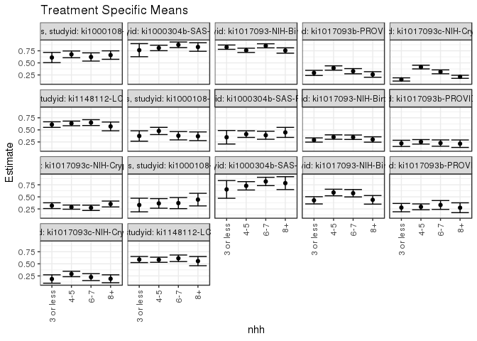

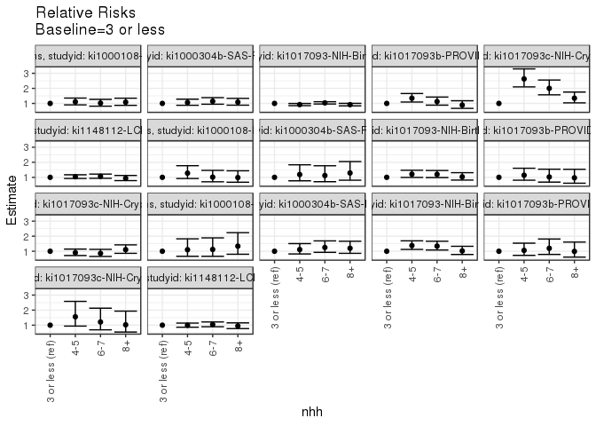

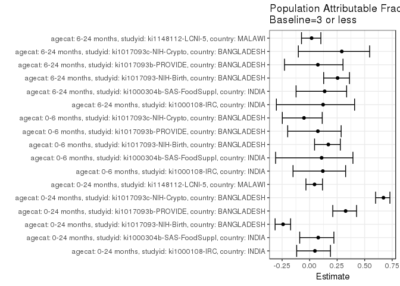

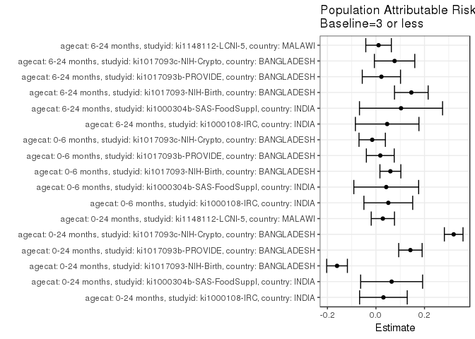

## Results Table

### Parameter: TSM

| agecat | studyid | country | intervention_level | baseline_level | estimate | ci_lower | ci_upper |
| --- | --- | --- | --- | --- | --- | --- | --- |
| 0-24 months | ki1000108-IRC | INDIA | 3 or less | NA | 0.6106764 | 0.5047337 | 0.7166191 |
| 0-24 months | ki1000108-IRC | INDIA | 4-5 | NA | 0.6760098 | 0.6058999 | 0.7461197 |
| 0-24 months | ki1000108-IRC | INDIA | 6-7 | NA | 0.6224179 | 0.5373474 | 0.7074884 |
| 0-24 months | ki1000108-IRC | INDIA | 8+ | NA | 0.6616410 | 0.5740129 | 0.7492691 |
| 0-24 months | ki1000304b-SAS-FoodSuppl | INDIA | 3 or less | NA | 0.7631579 | 0.6278220 | 0.8984938 |
| 0-24 months | ki1000304b-SAS-FoodSuppl | INDIA | 4-5 | NA | 0.8087432 | 0.7516931 | 0.8657933 |
| 0-24 months | ki1000304b-SAS-FoodSuppl | INDIA | 6-7 | NA | 0.8740157 | 0.8162349 | 0.9317966 |
| 0-24 months | ki1000304b-SAS-FoodSuppl | INDIA | 8+ | NA | 0.8285714 | 0.7401768 | 0.9169660 |
| 0-24 months | ki1017093-NIH-Birth | BANGLADESH | 3 or less | NA | 0.8248619 | 0.7802926 | 0.8694312 |
| 0-24 months | ki1017093-NIH-Birth | BANGLADESH | 4-5 | NA | 0.7598516 | 0.7159575 | 0.8037457 |
| 0-24 months | ki1017093-NIH-Birth | BANGLADESH | 6-7 | NA | 0.8529889 | 0.8109460 | 0.8950318 |
| 0-24 months | ki1017093-NIH-Birth | BANGLADESH | 8+ | NA | 0.7559449 | 0.7005946 | 0.8112952 |
| 0-24 months | ki1017093b-PROVIDE | BANGLADESH | 3 or less | NA | 0.2922845 | 0.2393993 | 0.3451697 |
| 0-24 months | ki1017093b-PROVIDE | BANGLADESH | 4-5 | NA | 0.3931876 | 0.3481025 | 0.4382727 |
| 0-24 months | ki1017093b-PROVIDE | BANGLADESH | 6-7 | NA | 0.3279465 | 0.2743432 | 0.3815498 |
| 0-24 months | ki1017093b-PROVIDE | BANGLADESH | 8+ | NA | 0.2599380 | 0.2022121 | 0.3176640 |
| 0-24 months | ki1017093c-NIH-Crypto | BANGLADESH | 3 or less | NA | 0.1572251 | 0.1239239 | 0.1905262 |
| 0-24 months | ki1017093c-NIH-Crypto | BANGLADESH | 4-5 | NA | 0.4133204 | 0.3751825 | 0.4514582 |
| 0-24 months | ki1017093c-NIH-Crypto | BANGLADESH | 6-7 | NA | 0.3148349 | 0.2746790 | 0.3549907 |
| 0-24 months | ki1017093c-NIH-Crypto | BANGLADESH | 8+ | NA | 0.2119651 | 0.1804255 | 0.2435048 |
| 0-24 months | ki1148112-LCNI-5 | MALAWI | 3 or less | NA | 0.6092815 | 0.5512441 | 0.6673190 |
| 0-24 months | ki1148112-LCNI-5 | MALAWI | 4-5 | NA | 0.6336643 | 0.5859516 | 0.6813769 |
| 0-24 months | ki1148112-LCNI-5 | MALAWI | 6-7 | NA | 0.6501650 | 0.5895459 | 0.7107842 |
| 0-24 months | ki1148112-LCNI-5 | MALAWI | 8+ | NA | 0.5715914 | 0.4811719 | 0.6620109 |
| 0-6 months | ki1000108-IRC | INDIA | 3 or less | NA | 0.3734757 | 0.2658802 | 0.4810713 |
| 0-6 months | ki1000108-IRC | INDIA | 4-5 | NA | 0.4771026 | 0.4023911 | 0.5518142 |
| 0-6 months | ki1000108-IRC | INDIA | 6-7 | NA | 0.3786161 | 0.2928551 | 0.4643771 |
| 0-6 months | ki1000108-IRC | INDIA | 8+ | NA | 0.3676428 | 0.2779564 | 0.4573292 |
| 0-6 months | ki1000304b-SAS-FoodSuppl | INDIA | 3 or less | NA | 0.3470173 | 0.2069982 | 0.4870363 |
| 0-6 months | ki1000304b-SAS-FoodSuppl | INDIA | 4-5 | NA | 0.4117930 | 0.3433146 | 0.4802715 |
| 0-6 months | ki1000304b-SAS-FoodSuppl | INDIA | 6-7 | NA | 0.3888289 | 0.3055513 | 0.4721065 |
| 0-6 months | ki1000304b-SAS-FoodSuppl | INDIA | 8+ | NA | 0.4472729 | 0.3434478 | 0.5510980 |
| 0-6 months | ki1017093-NIH-Birth | BANGLADESH | 3 or less | NA | 0.2902911 | 0.2466703 | 0.3339119 |
| 0-6 months | ki1017093-NIH-Birth | BANGLADESH | 4-5 | NA | 0.3513192 | 0.3056640 | 0.3969743 |
| 0-6 months | ki1017093-NIH-Birth | BANGLADESH | 6-7 | NA | 0.3476057 | 0.3017591 | 0.3934523 |
| 0-6 months | ki1017093-NIH-Birth | BANGLADESH | 8+ | NA | 0.3006371 | 0.2454872 | 0.3557869 |
| 0-6 months | ki1017093b-PROVIDE | BANGLADESH | 3 or less | NA | 0.2207110 | 0.1567897 | 0.2846323 |
| 0-6 months | ki1017093b-PROVIDE | BANGLADESH | 4-5 | NA | 0.2516895 | 0.2051194 | 0.2982596 |
| 0-6 months | ki1017093b-PROVIDE | BANGLADESH | 6-7 | NA | 0.2264537 | 0.1611312 | 0.2917762 |
| 0-6 months | ki1017093b-PROVIDE | BANGLADESH | 8+ | NA | 0.2137315 | 0.1365109 | 0.2909522 |
| 0-6 months | ki1017093c-NIH-Crypto | BANGLADESH | 3 or less | NA | 0.3176011 | 0.2579227 | 0.3772795 |
| 0-6 months | ki1017093c-NIH-Crypto | BANGLADESH | 4-5 | NA | 0.2872933 | 0.2442371 | 0.3303495 |
| 0-6 months | ki1017093c-NIH-Crypto | BANGLADESH | 6-7 | NA | 0.2729600 | 0.2181939 | 0.3277260 |
| 0-6 months | ki1017093c-NIH-Crypto | BANGLADESH | 8+ | NA | 0.3520900 | 0.2913323 | 0.4128478 |
| 6-24 months | ki1000108-IRC | INDIA | 3 or less | NA | 0.3309578 | 0.1902607 | 0.4716549 |
| 6-24 months | ki1000108-IRC | INDIA | 4-5 | NA | 0.3643949 | 0.2647270 | 0.4640628 |
| 6-24 months | ki1000108-IRC | INDIA | 6-7 | NA | 0.3707064 | 0.2563905 | 0.4850222 |
| 6-24 months | ki1000108-IRC | INDIA | 8+ | NA | 0.4429306 | 0.3127135 | 0.5731478 |
| 6-24 months | ki1000304b-SAS-FoodSuppl | INDIA | 3 or less | NA | 0.6538462 | 0.4706024 | 0.8370899 |
| 6-24 months | ki1000304b-SAS-FoodSuppl | INDIA | 4-5 | NA | 0.7281553 | 0.6420565 | 0.8142542 |
| 6-24 months | ki1000304b-SAS-FoodSuppl | INDIA | 6-7 | NA | 0.8181818 | 0.7318558 | 0.9045078 |
| 6-24 months | ki1000304b-SAS-FoodSuppl | INDIA | 8+ | NA | 0.7837838 | 0.6508654 | 0.9167021 |
| 6-24 months | ki1017093-NIH-Birth | BANGLADESH | 3 or less | NA | 0.4281671 | 0.3534074 | 0.5029268 |
| 6-24 months | ki1017093-NIH-Birth | BANGLADESH | 4-5 | NA | 0.5897972 | 0.5218260 | 0.6577683 |
| 6-24 months | ki1017093-NIH-Birth | BANGLADESH | 6-7 | NA | 0.5748202 | 0.4984542 | 0.6511862 |
| 6-24 months | ki1017093-NIH-Birth | BANGLADESH | 8+ | NA | 0.4381234 | 0.3493256 | 0.5269212 |
| 6-24 months | ki1017093b-PROVIDE | BANGLADESH | 3 or less | NA | 0.2773301 | 0.1910508 | 0.3636094 |
| 6-24 months | ki1017093b-PROVIDE | BANGLADESH | 4-5 | NA | 0.2933259 | 0.2325248 | 0.3541269 |
| 6-24 months | ki1017093b-PROVIDE | BANGLADESH | 6-7 | NA | 0.3317431 | 0.2402869 | 0.4231993 |
| 6-24 months | ki1017093b-PROVIDE | BANGLADESH | 8+ | NA | 0.2748981 | 0.1729335 | 0.3768626 |
| 6-24 months | ki1017093c-NIH-Crypto | BANGLADESH | 3 or less | NA | 0.1860909 | 0.0993178 | 0.2728641 |
| 6-24 months | ki1017093c-NIH-Crypto | BANGLADESH | 4-5 | NA | 0.2898032 | 0.2334729 | 0.3461335 |
| 6-24 months | ki1017093c-NIH-Crypto | BANGLADESH | 6-7 | NA | 0.2254768 | 0.1543760 | 0.2965776 |
| 6-24 months | ki1017093c-NIH-Crypto | BANGLADESH | 8+ | NA | 0.1907369 | 0.1086809 | 0.2727930 |
| 6-24 months | ki1148112-LCNI-5 | MALAWI | 3 or less | NA | 0.5892241 | 0.5261893 | 0.6522588 |
| 6-24 months | ki1148112-LCNI-5 | MALAWI | 4-5 | NA | 0.5844992 | 0.5317708 | 0.6372277 |
| 6-24 months | ki1148112-LCNI-5 | MALAWI | 6-7 | NA | 0.6147640 | 0.5472247 | 0.6823032 |
| 6-24 months | ki1148112-LCNI-5 | MALAWI | 8+ | NA | 0.5563802 | 0.4610746 | 0.6516858 |

### Parameter: E(Y)

| agecat | studyid | country | intervention_level | baseline_level | estimate | ci_lower | ci_upper |
| --- | --- | --- | --- | --- | --- | --- | --- |
| 0-24 months | ki1000108-IRC | INDIA | NA | NA | 0.6414634 | 0.5949863 | 0.6879405 |
| 0-24 months | ki1000304b-SAS-FoodSuppl | INDIA | NA | NA | 0.8277512 | 0.7915095 | 0.8639929 |
| 0-24 months | ki1017093-NIH-Birth | BANGLADESH | NA | NA | 0.6645469 | 0.6276196 | 0.7014742 |
| 0-24 months | ki1017093b-PROVIDE | BANGLADESH | NA | NA | 0.4342857 | 0.3975409 | 0.4710305 |
| 0-24 months | ki1017093c-NIH-Crypto | BANGLADESH | NA | NA | 0.4775726 | 0.4419904 | 0.5131548 |
| 0-24 months | ki1148112-LCNI-5 | MALAWI | NA | NA | 0.6376989 | 0.6047193 | 0.6706785 |
| 0-6 months | ki1000108-IRC | INDIA | NA | NA | 0.4243902 | 0.3764905 | 0.4722900 |
| 0-6 months | ki1000304b-SAS-FoodSuppl | INDIA | NA | NA | 0.3894231 | 0.3425088 | 0.4363374 |
| 0-6 months | ki1017093-NIH-Birth | BANGLADESH | NA | NA | 0.3497615 | 0.3124631 | 0.3870600 |
| 0-6 months | ki1017093b-PROVIDE | BANGLADESH | NA | NA | 0.2385714 | 0.2069753 | 0.2701675 |
| 0-6 months | ki1017093c-NIH-Crypto | BANGLADESH | NA | NA | 0.3021108 | 0.2694011 | 0.3348205 |
| 6-24 months | ki1000108-IRC | INDIA | NA | NA | 0.3771186 | 0.3151523 | 0.4390850 |
| 6-24 months | ki1000304b-SAS-FoodSuppl | INDIA | NA | NA | 0.7572016 | 0.7031798 | 0.8112234 |
| 6-24 months | ki1017093-NIH-Birth | BANGLADESH | NA | NA | 0.5739130 | 0.5216565 | 0.6261696 |
| 6-24 months | ki1017093b-PROVIDE | BANGLADESH | NA | NA | 0.2997812 | 0.2577294 | 0.3418330 |
| 6-24 months | ki1017093c-NIH-Crypto | BANGLADESH | NA | NA | 0.2628458 | 0.2244546 | 0.3012371 |
| 6-24 months | ki1148112-LCNI-5 | MALAWI | NA | NA | 0.6000000 | 0.5639396 | 0.6360604 |

### Parameter: RR

| agecat | studyid | country | intervention_level | baseline_level | estimate | ci_lower | ci_upper |
| --- | --- | --- | --- | --- | --- | --- | --- |
| 0-24 months | ki1000108-IRC | INDIA | 3 or less | 3 or less | 1.0000000 | 1.0000000 | 1.0000000 |
| 0-24 months | ki1000108-IRC | INDIA | 4-5 | 3 or less | 1.1069853 | 0.9046847 | 1.3545231 |
| 0-24 months | ki1000108-IRC | INDIA | 6-7 | 3 or less | 1.0192270 | 0.8175173 | 1.2707056 |
| 0-24 months | ki1000108-IRC | INDIA | 8+ | 3 or less | 1.0834560 | 0.8715455 | 1.3468909 |
| 0-24 months | ki1000304b-SAS-FoodSuppl | INDIA | 3 or less | 3 or less | 1.0000000 | 1.0000000 | 1.0000000 |
| 0-24 months | ki1000304b-SAS-FoodSuppl | INDIA | 4-5 | 3 or less | 1.0597324 | 0.8756092 | 1.2825731 |
| 0-24 months | ki1000304b-SAS-FoodSuppl | INDIA | 6-7 | 3 or less | 1.1452620 | 0.9477874 | 1.3838812 |
| 0-24 months | ki1000304b-SAS-FoodSuppl | INDIA | 8+ | 3 or less | 1.0857143 | 0.8827484 | 1.3353471 |
| 0-24 months | ki1017093-NIH-Birth | BANGLADESH | 3 or less | 3 or less | 1.0000000 | 1.0000000 | 1.0000000 |
| 0-24 months | ki1017093-NIH-Birth | BANGLADESH | 4-5 | 3 or less | 0.9211864 | 0.8518499 | 0.9961666 |
| 0-24 months | ki1017093-NIH-Birth | BANGLADESH | 6-7 | 3 or less | 1.0340990 | 0.9611276 | 1.1126106 |
| 0-24 months | ki1017093-NIH-Birth | BANGLADESH | 8+ | 3 or less | 0.9164503 | 0.8372448 | 1.0031488 |
| 0-24 months | ki1017093b-PROVIDE | BANGLADESH | 3 or less | 3 or less | 1.0000000 | 1.0000000 | 1.0000000 |
| 0-24 months | ki1017093b-PROVIDE | BANGLADESH | 4-5 | 3 or less | 1.3452224 | 1.0915114 | 1.6579059 |
| 0-24 months | ki1017093b-PROVIDE | BANGLADESH | 6-7 | 3 or less | 1.1220113 | 0.8854161 | 1.4218279 |
| 0-24 months | ki1017093b-PROVIDE | BANGLADESH | 8+ | 3 or less | 0.8893323 | 0.6718509 | 1.1772135 |
| 0-24 months | ki1017093c-NIH-Crypto | BANGLADESH | 3 or less | 3 or less | 1.0000000 | 1.0000000 | 1.0000000 |
| 0-24 months | ki1017093c-NIH-Crypto | BANGLADESH | 4-5 | 3 or less | 2.6288455 | 2.0988768 | 3.2926318 |
| 0-24 months | ki1017093c-NIH-Crypto | BANGLADESH | 6-7 | 3 or less | 2.0024471 | 1.5704237 | 2.5533201 |
| 0-24 months | ki1017093c-NIH-Crypto | BANGLADESH | 8+ | 3 or less | 1.3481639 | 1.0357987 | 1.7547288 |
| 0-24 months | ki1148112-LCNI-5 | MALAWI | 3 or less | 3 or less | 1.0000000 | 1.0000000 | 1.0000000 |
| 0-24 months | ki1148112-LCNI-5 | MALAWI | 4-5 | 3 or less | 1.0400189 | 0.9242519 | 1.1702862 |
| 0-24 months | ki1148112-LCNI-5 | MALAWI | 6-7 | 3 or less | 1.0671012 | 0.9368756 | 1.2154281 |
| 0-24 months | ki1148112-LCNI-5 | MALAWI | 8+ | 3 or less | 0.9381401 | 0.7821993 | 1.1251695 |
| 0-6 months | ki1000108-IRC | INDIA | 3 or less | 3 or less | 1.0000000 | 1.0000000 | 1.0000000 |
| 0-6 months | ki1000108-IRC | INDIA | 4-5 | 3 or less | 1.2774661 | 0.9207017 | 1.7724739 |
| 0-6 months | ki1000108-IRC | INDIA | 6-7 | 3 or less | 1.0137636 | 0.7030210 | 1.4618575 |
| 0-6 months | ki1000108-IRC | INDIA | 8+ | 3 or less | 0.9843820 | 0.6751170 | 1.4353184 |
| 0-6 months | ki1000304b-SAS-FoodSuppl | INDIA | 3 or less | 3 or less | 1.0000000 | 1.0000000 | 1.0000000 |
| 0-6 months | ki1000304b-SAS-FoodSuppl | INDIA | 4-5 | 3 or less | 1.1866644 | 0.7686122 | 1.8320974 |
| 0-6 months | ki1000304b-SAS-FoodSuppl | INDIA | 6-7 | 3 or less | 1.1204887 | 0.7097530 | 1.7689179 |
| 0-6 months | ki1000304b-SAS-FoodSuppl | INDIA | 8+ | 3 or less | 1.2889068 | 0.8112935 | 2.0476940 |
| 0-6 months | ki1017093-NIH-Birth | BANGLADESH | 3 or less | 3 or less | 1.0000000 | 1.0000000 | 1.0000000 |
| 0-6 months | ki1017093-NIH-Birth | BANGLADESH | 4-5 | 3 or less | 1.2102307 | 0.9956431 | 1.4710676 |
| 0-6 months | ki1017093-NIH-Birth | BANGLADESH | 6-7 | 3 or less | 1.1974383 | 0.9854714 | 1.4549976 |
| 0-6 months | ki1017093-NIH-Birth | BANGLADESH | 8+ | 3 or less | 1.0356400 | 0.8195035 | 1.3087805 |
| 0-6 months | ki1017093b-PROVIDE | BANGLADESH | 3 or less | 3 or less | 1.0000000 | 1.0000000 | 1.0000000 |
| 0-6 months | ki1017093b-PROVIDE | BANGLADESH | 4-5 | 3 or less | 1.1403579 | 0.8104229 | 1.6046143 |
| 0-6 months | ki1017093b-PROVIDE | BANGLADESH | 6-7 | 3 or less | 1.0260191 | 0.6828113 | 1.5417365 |
| 0-6 months | ki1017093b-PROVIDE | BANGLADESH | 8+ | 3 or less | 0.9683774 | 0.6110027 | 1.5347800 |
| 0-6 months | ki1017093c-NIH-Crypto | BANGLADESH | 3 or less | 3 or less | 1.0000000 | 1.0000000 | 1.0000000 |
| 0-6 months | ki1017093c-NIH-Crypto | BANGLADESH | 4-5 | 3 or less | 0.9045727 | 0.7153437 | 1.1438581 |
| 0-6 months | ki1017093c-NIH-Crypto | BANGLADESH | 6-7 | 3 or less | 0.8594428 | 0.6555052 | 1.1268285 |
| 0-6 months | ki1017093c-NIH-Crypto | BANGLADESH | 8+ | 3 or less | 1.1085919 | 0.8619896 | 1.4257434 |
| 6-24 months | ki1000108-IRC | INDIA | 3 or less | 3 or less | 1.0000000 | 1.0000000 | 1.0000000 |
| 6-24 months | ki1000108-IRC | INDIA | 4-5 | 3 or less | 1.1010314 | 0.6638720 | 1.8260601 |
| 6-24 months | ki1000108-IRC | INDIA | 6-7 | 3 or less | 1.1201016 | 0.6644613 | 1.8881878 |
| 6-24 months | ki1000108-IRC | INDIA | 8+ | 3 or less | 1.3383297 | 0.8011193 | 2.2357798 |
| 6-24 months | ki1000304b-SAS-FoodSuppl | INDIA | 3 or less | 3 or less | 1.0000000 | 1.0000000 | 1.0000000 |
| 6-24 months | ki1000304b-SAS-FoodSuppl | INDIA | 4-5 | 3 or less | 1.1136493 | 0.8215720 | 1.5095631 |
| 6-24 months | ki1000304b-SAS-FoodSuppl | INDIA | 6-7 | 3 or less | 1.2513369 | 0.9275155 | 1.6882133 |
| 6-24 months | ki1000304b-SAS-FoodSuppl | INDIA | 8+ | 3 or less | 1.1987281 | 0.8638907 | 1.6633461 |
| 6-24 months | ki1017093-NIH-Birth | BANGLADESH | 3 or less | 3 or less | 1.0000000 | 1.0000000 | 1.0000000 |
| 6-24 months | ki1017093-NIH-Birth | BANGLADESH | 4-5 | 3 or less | 1.3774929 | 1.1212253 | 1.6923331 |
| 6-24 months | ki1017093-NIH-Birth | BANGLADESH | 6-7 | 3 or less | 1.3425136 | 1.0829655 | 1.6642661 |
| 6-24 months | ki1017093-NIH-Birth | BANGLADESH | 8+ | 3 or less | 1.0232533 | 0.7864100 | 1.3314267 |
| 6-24 months | ki1017093b-PROVIDE | BANGLADESH | 3 or less | 3 or less | 1.0000000 | 1.0000000 | 1.0000000 |
| 6-24 months | ki1017093b-PROVIDE | BANGLADESH | 4-5 | 3 or less | 1.0576777 | 0.7277709 | 1.5371348 |
| 6-24 months | ki1017093b-PROVIDE | BANGLADESH | 6-7 | 3 or less | 1.1962030 | 0.7894320 | 1.8125711 |
| 6-24 months | ki1017093b-PROVIDE | BANGLADESH | 8+ | 3 or less | 0.9912305 | 0.6107013 | 1.6088682 |
| 6-24 months | ki1017093c-NIH-Crypto | BANGLADESH | 3 or less | 3 or less | 1.0000000 | 1.0000000 | 1.0000000 |
| 6-24 months | ki1017093c-NIH-Crypto | BANGLADESH | 4-5 | 3 or less | 1.5573204 | 0.9395553 | 2.5812711 |
| 6-24 months | ki1017093c-NIH-Crypto | BANGLADESH | 6-7 | 3 or less | 1.2116484 | 0.6899240 | 2.1279035 |
| 6-24 months | ki1017093c-NIH-Crypto | BANGLADESH | 8+ | 3 or less | 1.0249662 | 0.5435664 | 1.9327090 |
| 6-24 months | ki1148112-LCNI-5 | MALAWI | 3 or less | 3 or less | 1.0000000 | 1.0000000 | 1.0000000 |
| 6-24 months | ki1148112-LCNI-5 | MALAWI | 4-5 | 3 or less | 0.9919813 | 0.8647725 | 1.1379025 |
| 6-24 months | ki1148112-LCNI-5 | MALAWI | 6-7 | 3 or less | 1.0433450 | 0.8967253 | 1.2139378 |
| 6-24 months | ki1148112-LCNI-5 | MALAWI | 8+ | 3 or less | 0.9442591 | 0.7730222 | 1.1534277 |

### Parameter: PAR

| agecat | studyid | country | intervention_level | baseline_level | estimate | ci_lower | ci_upper |
| --- | --- | --- | --- | --- | --- | --- | --- |
| 0-24 months | ki1000108-IRC | INDIA | 3 or less | NA | 0.0307870 | -0.0673284 | 0.1289024 |
| 0-24 months | ki1000304b-SAS-FoodSuppl | INDIA | 3 or less | NA | 0.0645933 | -0.0630747 | 0.1922613 |
| 0-24 months | ki1017093-NIH-Birth | BANGLADESH | 3 or less | NA | -0.1603150 | -0.2029944 | -0.1176356 |
| 0-24 months | ki1017093b-PROVIDE | BANGLADESH | 3 or less | NA | 0.1420012 | 0.0937168 | 0.1902856 |
| 0-24 months | ki1017093c-NIH-Crypto | BANGLADESH | 3 or less | NA | 0.3203475 | 0.2819163 | 0.3587787 |
| 0-24 months | ki1148112-LCNI-5 | MALAWI | 3 or less | NA | 0.0284174 | -0.0195058 | 0.0763406 |
| 0-6 months | ki1000108-IRC | INDIA | 3 or less | NA | 0.0509145 | -0.0495926 | 0.1514216 |
| 0-6 months | ki1000304b-SAS-FoodSuppl | INDIA | 3 or less | NA | 0.0424058 | -0.0911632 | 0.1759748 |
| 0-6 months | ki1017093-NIH-Birth | BANGLADESH | 3 or less | NA | 0.0594704 | 0.0163958 | 0.1025451 |
| 0-6 months | ki1017093b-PROVIDE | BANGLADESH | 3 or less | NA | 0.0178604 | -0.0395126 | 0.0752335 |
| 0-6 months | ki1017093c-NIH-Crypto | BANGLADESH | 3 or less | NA | -0.0154903 | -0.0697802 | 0.0387996 |
| 6-24 months | ki1000108-IRC | INDIA | 3 or less | NA | 0.0461609 | -0.0847421 | 0.1770638 |
| 6-24 months | ki1000304b-SAS-FoodSuppl | INDIA | 3 or less | NA | 0.1033555 | -0.0678495 | 0.2745605 |
| 6-24 months | ki1017093-NIH-Birth | BANGLADESH | 3 or less | NA | 0.1457459 | 0.0764050 | 0.2150869 |
| 6-24 months | ki1017093b-PROVIDE | BANGLADESH | 3 or less | NA | 0.0224511 | -0.0563587 | 0.1012609 |
| 6-24 months | ki1017093c-NIH-Crypto | BANGLADESH | 3 or less | NA | 0.0767549 | -0.0064570 | 0.1599668 |
| 6-24 months | ki1148112-LCNI-5 | MALAWI | 3 or less | NA | 0.0107759 | -0.0418975 | 0.0634493 |

### Parameter: PAF

| agecat | studyid | country | intervention_level | baseline_level | estimate | ci_lower | ci_upper |
| --- | --- | --- | --- | --- | --- | --- | --- |
| 0-24 months | ki1000108-IRC | INDIA | 3 or less | NA | 0.0479950 | -0.1177277 | 0.1891463 |
| 0-24 months | ki1000304b-SAS-FoodSuppl | INDIA | 3 or less | NA | 0.0780347 | -0.0902029 | 0.2203102 |
| 0-24 months | ki1017093-NIH-Birth | BANGLADESH | 3 or less | NA | -0.2412396 | -0.3136968 | -0.1727787 |
| 0-24 months | ki1017093b-PROVIDE | BANGLADESH | 3 or less | NA | 0.3269765 | 0.2102158 | 0.4264755 |
| 0-24 months | ki1017093c-NIH-Crypto | BANGLADESH | 3 or less | NA | 0.6707829 | 0.5994618 | 0.7294043 |
| 0-24 months | ki1148112-LCNI-5 | MALAWI | 3 or less | NA | 0.0445624 | -0.0336480 | 0.1168550 |
| 0-6 months | ki1000108-IRC | INDIA | 3 or less | NA | 0.1199709 | -0.1507819 | 0.3270218 |
| 0-6 months | ki1000304b-SAS-FoodSuppl | INDIA | 3 or less | NA | 0.1088939 | -0.3091566 | 0.3934492 |
| 0-6 months | ki1017093-NIH-Birth | BANGLADESH | 3 or less | NA | 0.1700314 | 0.0446837 | 0.2789321 |
| 0-6 months | ki1017093b-PROVIDE | BANGLADESH | 3 or less | NA | 0.0748641 | -0.1993135 | 0.2863614 |
| 0-6 months | ki1017093c-NIH-Crypto | BANGLADESH | 3 or less | NA | -0.0512735 | -0.2481936 | 0.1145796 |
| 6-24 months | ki1000108-IRC | INDIA | 3 or less | NA | 0.1224041 | -0.3020693 | 0.4084995 |
| 6-24 months | ki1000304b-SAS-FoodSuppl | INDIA | 3 or less | NA | 0.1364967 | -0.1231626 | 0.3361264 |
| 6-24 months | ki1017093-NIH-Birth | BANGLADESH | 3 or less | NA | 0.2539512 | 0.1275777 | 0.3620191 |
| 6-24 months | ki1017093b-PROVIDE | BANGLADESH | 3 or less | NA | 0.0748915 | -0.2283086 | 0.3032486 |
| 6-24 months | ki1017093c-NIH-Crypto | BANGLADESH | 3 or less | NA | 0.2920149 | -0.1026039 | 0.5454007 |
| 6-24 months | ki1148112-LCNI-5 | MALAWI | 3 or less | NA | 0.0179599 | -0.0738483 | 0.1019190 |